# Reproducible Research Peer Assessment 01

Load the plyr library

```r
library(plyr)
library(lattice)
```

## Loading and pre-processing the data

1 Load the data

```r
rawData <- read.csv("activity.csv", header=TRUE)
```

2 Process/transform the data (if necessary) into a format suitable for your analysis

Not required in my opinion

## What is mean total number of steps taken per day?

1 Calculate the total number of steps taken per day

```r
sumOfSteps <- ddply(rawData,~date, summarise, sum=sum(steps))
```

2 Make a histogram of the total number of steps taken each day

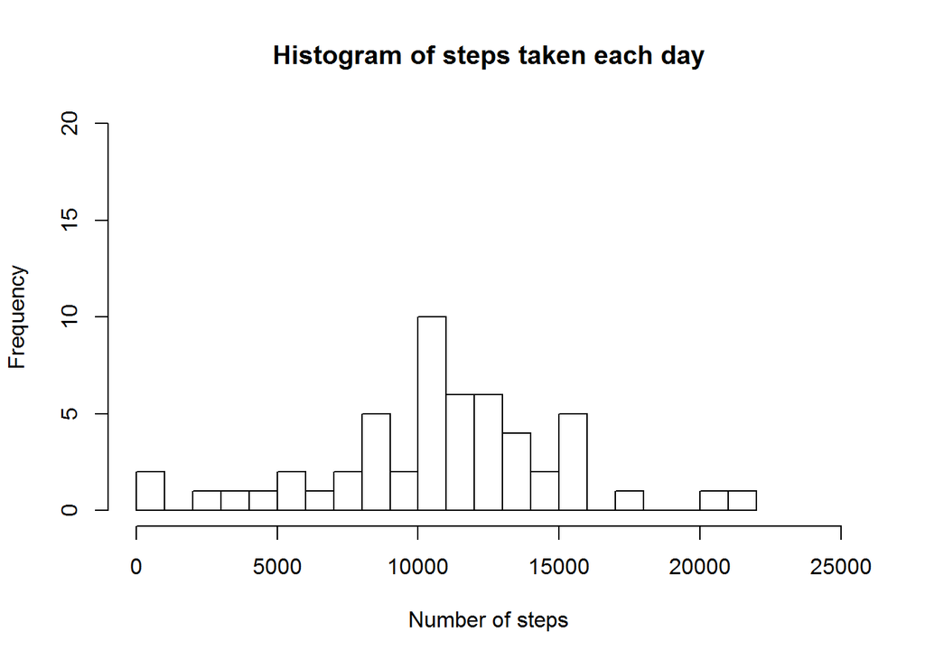

```r
hist(sumOfSteps$sum,
     breaks=20,
     main="Histogram of steps taken each day",
     xlab="Number of steps",
     ylim=c(0,20),
     xlim=c(0,25000))
```

3 Calculate and report the mean and median of the total number of steps taken per day

```r
meanOfSteps <- ddply(rawData,~date, summarise, steps=mean(steps))
```

Mean of Steps

```
##          date      steps
## 1  2012-10-01         NA
## 2  2012-10-02  0.4375000
## 3  2012-10-03 39.4166667
## 4  2012-10-04 42.0694444
## 5  2012-10-05 46.1597222
## 6  2012-10-06 53.5416667
## 7  2012-10-07 38.2465278
## 8  2012-10-08         NA
## 9  2012-10-09 44.4826389
## 10 2012-10-10 34.3750000
## 11 2012-10-11 35.7777778
## 12 2012-10-12 60.3541667
## 13 2012-10-13 43.1458333
## 14 2012-10-14 52.4236111
```

[output cut: 47 more lines]

```r
medianOfSteps <- ddply(rawData,~date, summarise, steps=median(steps))
```

Median of Steps

```
##          date steps
## 1  2012-10-01    NA
## 2  2012-10-02     0
## 3  2012-10-03     0
## 4  2012-10-04     0
## 5  2012-10-05     0
## 6  2012-10-06     0
## 7  2012-10-07     0
## 8  2012-10-08    NA
## 9  2012-10-09     0
## 10 2012-10-10     0
## 11 2012-10-11     0
## 12 2012-10-12     0
## 13 2012-10-13     0
## 14 2012-10-14     0
```

[output cut: 47 more lines]

## What is the average daily activity pattern?

1 Make a time series plot (i.e. type = “l”) of the 5-minute interval (x-axis) and the average number of steps taken, averaged across all days (y-axis)

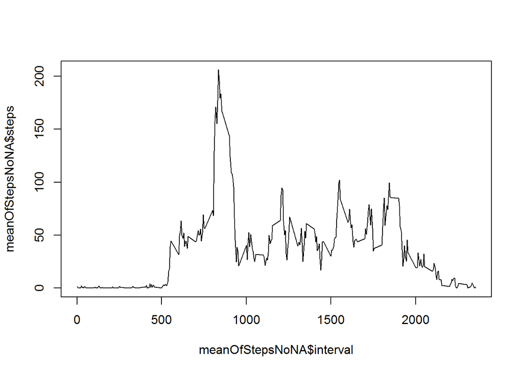

```r
meanOfStepsNoNA <- ddply(na.omit(rawData),~interval, summarise, steps=mean(steps))
plot(meanOfStepsNoNA$interval, meanOfStepsNoNA$steps, type="l")
```

2 Which 5-minute interval, on average across all the days in the dataset, contains the maximum number of steps?

```r
tail(meanOfStepsNoNA[ order(meanOfStepsNoNA[,2]),], n=1)
```

```
##     interval    steps
## 104      835 206.1698
```

## Imputing missing values

1 Calculate and report the total number of missing values in the dataset (i.e. the total number of rows with NAs)

```r
count(rawData$steps==NA)
```

```
##    x  freq
## 1 NA 17568
```

2 Devise a strategy for filling in all of the missing values in the dataset. The strategy does not need to be sophisticated. For example, you could use the mean/median for that day, or the mean for that 5-minute interval, etc.

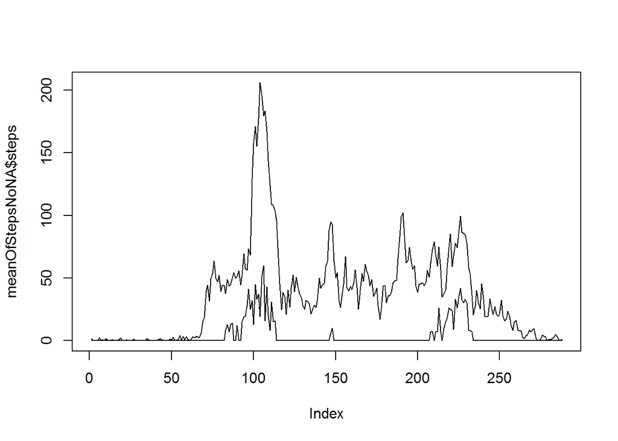

```r
medianOfStepsNoNA <- ddply(na.omit(rawData),~interval, summarise, steps=median(steps))
plot(meanOfStepsNoNA$steps, type="l")
lines(medianOfStepsNoNA$steps)
```

My strategy would be to replace with the mean value of that timepoint

3 Create a new dataset that is equal to the original dataset but with the missing data filled in.

```r
cleanData <- rawData

for (ii in 1:dim(rawData)[1]){
  if (is.na(rawData$steps[ii])){
    int <- rawData$interval[ii]
    cleanData$steps[ii] <- round(meanOfStepsNoNA[meanOfStepsNoNA$interval==int,]$steps)
  }
}
```

4 Make a histogram of the total number of steps taken each day and Calculate and report the mean and median total number of steps taken per day. Do these values differ from the estimates from the first part of the assignment? What is the impact of imputing missing data on the estimates of the total daily number of steps?

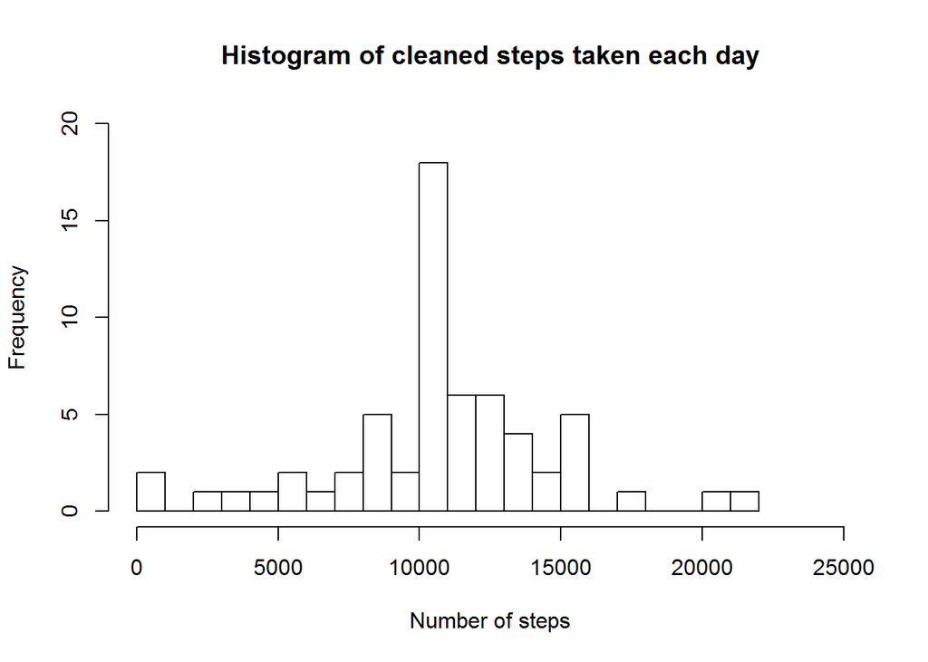

```r
sumOfCleanedSteps <- ddply(cleanData,~date, summarise, sum=sum(steps))

hist(sumOfCleanedSteps$sum,
     breaks=20,
     main="Histogram of cleaned steps taken each day",
     xlab="Number of steps",
     ylim=c(0,20),
     xlim=c(0,25000))
```

```r
meanOfCleanedSteps <- ddply(cleanData,~date, summarise, steps=mean(steps))
ddply(cleanData,~date, summarise, steps=mean(steps))
```

```
##          date      steps
## 1  2012-10-01 37.3680556
## 2  2012-10-02  0.4375000
## 3  2012-10-03 39.4166667
## 4  2012-10-04 42.0694444
## 5  2012-10-05 46.1597222
## 6  2012-10-06 53.5416667
## 7  2012-10-07 38.2465278
## 8  2012-10-08 37.3680556
## 9  2012-10-09 44.4826389
## 10 2012-10-10 34.3750000
## 11 2012-10-11 35.7777778
## 12 2012-10-12 60.3541667
## 13 2012-10-13 43.1458333
## 14 2012-10-14 52.4236111
```

[output cut: 47 more lines]

```r
medianOfCleanedSteps <- ddply(cleanData,~date, summarise, steps=median(steps))
ddply(cleanData,~date, summarise, steps=median(steps))
```

```
##          date steps
## 1  2012-10-01  34.5
## 2  2012-10-02   0.0
## 3  2012-10-03   0.0
## 4  2012-10-04   0.0
## 5  2012-10-05   0.0
## 6  2012-10-06   0.0
## 7  2012-10-07   0.0
## 8  2012-10-08  34.5
## 9  2012-10-09   0.0
## 10 2012-10-10   0.0
## 11 2012-10-11   0.0
## 12 2012-10-12   0.0
## 13 2012-10-13   0.0
## 14 2012-10-14   0.0
```

[output cut: 47 more lines]

Are there differences in activity patterns between weekdays and weekends? Yes, the graphs show a slight difference in the pattern of steps. -

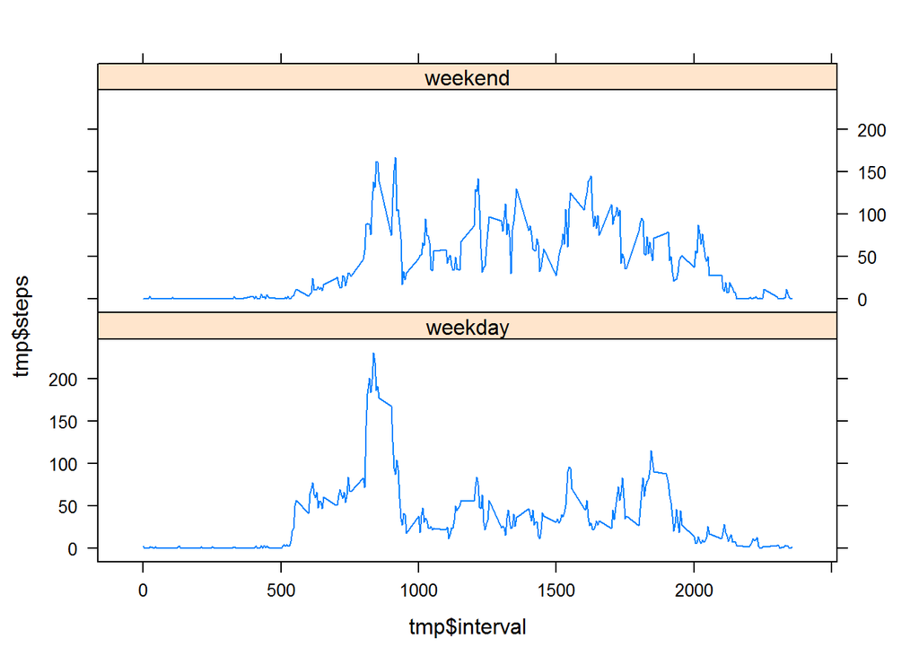

```r
cleanData$DoW <- ifelse( weekdays(as.Date(cleanData$date)) == "Saturday"| weekdays(as.Date(cleanData$date)) =="Sunday" , "weekend" , "weekday" )

tmp <- ddply(cleanData,~interval*DoW, summarise, steps=mean(steps))

xyplot(tmp$steps~tmp$interval | as.factor(tmp$DoW), type="l", layout=c(1,2))
```